# R Notebook

# Libraries

```r
library(tidyverse)
library(CodeClanData)
library(scales)
```

# Data

```r
qb_revenue <- qb_revenue_breakdown
qb_monthly_sales <- qb_monthly_sales
qb_competitors <- qb_competitors
qb_device <- qb_device_data
```

# 2.1 Part 1

## Q1: Take the data in the dataset qb_revenue_breakdown and make a stacked bar chart showing the sources of revenue across the two years in the dataset.

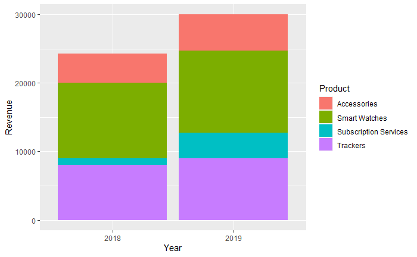

```r
qb_revenue %>%
  ggplot(aes(x = Year,
             y = Revenue,
             fill = Product)) +
  geom_col()
```

```r
  labs(x = "Year",
       y = "Revenue",
       title = "Sources of revenue in 2018 and 2019")
```

```
$x
[1] "Year"

$y
[1] "Revenue"

$title
[1] "Sources of revenue in 2018 and 2019"

attr(,"class")
[1] "labels"
```

## Q2: Make a line chart showing monthly sales of the “flagship product” - the ‘KwikBit Unit 1’ - over the last year. This data is inside qb_monthly_sales, but you will need to use filter() or subset() (base R).

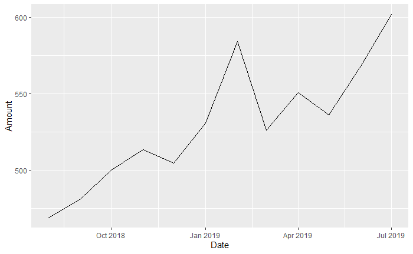

```r
qb_monthly_sales %>%
  filter(Cashflow == "Kwikbit Unit 1 Sales") %>%
  ggplot(aes(x = Date,
             y = Amount)) +
  geom_line()
```

```r
  labs(x = "Date",
       y = "Amount",
       title = "Monthly Sales of Kwikbit Unit 1",
       subtitle = "Data from monthly sales\n")
```

```
$x
[1] "Date"

$y
[1] "Amount"

$title
[1] "Monthly Sales of Kwikbit Unit 1"

$subtitle
[1] "Data from monthly sales\n"

attr(,"class")
[1] "labels"
```

## Q3: Make a line chart showing monthly revenue and costs over the last year. This data is also in qb_monthly_sales.

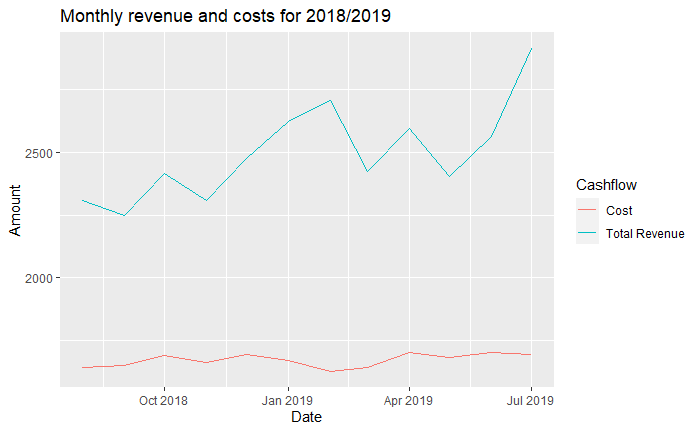

```r
qb_monthly_sales %>%
  filter(Cashflow != "Kwikbit Unit 1 Sales") %>%
  ggplot(aes(x = Date,
             y = Amount,
             colour = Cashflow)) +
  geom_line() +
  labs(x = "Date",
       y = "Amount",
       title = "Monthly revenue and costs for 2018/2019",
       fill = "Cash flow")
```

## Q4: Show annual sales of personal fitness trackers over the last 5 years broken down by company as a ribbon plot (use geom_area). This data is in qb_competitors.

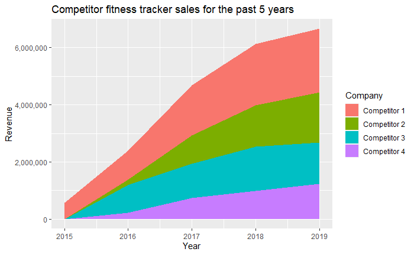

```r
qb_competitors %>%
  ggplot(aes(x = Year,
             y = Revenue,
             fill = Company)) +
  geom_area() +
  scale_y_continuous(labels = scales::comma) +
  labs(title = "Competitor fitness tracker sales for the past 5 years")
```

## Q5: Now show the sales from the four competitors as a line graph. Include an extra layer that shows the data points used to make the lines.

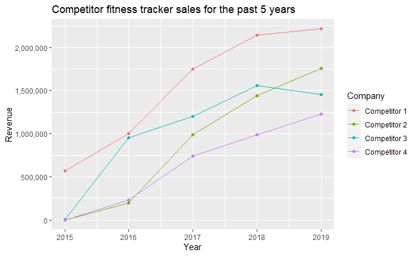

```r
qb_competitors %>%
  ggplot(aes(x = Year,
             y = Revenue,
             colour = Company)) +
  geom_line() +
  geom_point() +
  scale_y_continuous(labels = scales::comma) +
  labs(title = "Competitor fitness tracker sales for the past 5 years")
```

## Q6: Now the company wants to compare the number of steps that their device counts vs. their competitors. Make a line graph of the number of steps throughout time, and use faceting to compare between companies and people. The data for this is in qb_device_data.

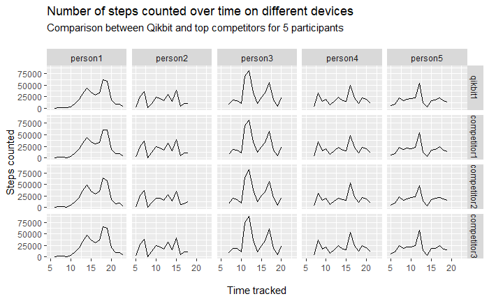

```r
qb_device %>%
  group_by(device, id, hours) %>%
  summarise(total_steps_counted = sum(counts)) %>%
  ggplot(aes(x = hours,
         y = total_steps_counted)) +
  geom_line() +
  facet_grid(device ~ id) +
  labs(x = "\nTime tracked",
       y = "Steps counted",
       title = "Number of steps counted over time on different devices",
       subtitle = "Comparison between Qikbit and top competitors for 5 participants\n")
```

# 2.2 Part 2

```r
qb_theme <- function() {
  theme(
    #add white background
    panel.background = element_blank,
    #modify grid
    panel.grid.major.x = element_line(colour = "#B6A7B5",
                                      size = 0.25),
    panel.grid.minor.x = element_blank(),
    panel.grid.major.y = element_line(colour = "#B6A7B5",
                                      size = 0.5),
    panel.grid.minor.y = element_blank(),
    #axis text slightly smaller than default
    axis.text = element_text(size = rel(0.75)),
    #axis titles slightly larger than default
    axis.title = element_text(size = rel(1.5)),




  )
}
```